## Welcome to Data Science!

Today, we’ll be working on getting you set up with the tools you will need for this class. Once you are set up, we’ll do what we’re here to do: analyze data!

Here’s what we need to get done today:

1. Getting started with R
2. Getting started with RStudio
3. Starting assignment 1, “Hello, world!”

## Introductions

We need two basic sets of tools for this class. We will need `R` to analyze data. We will need `RStudio` to help us interface with R and to produce documentation of our results.

## Installing R

R is going to be the only programming language we will use. R is an extensible statistical programming environment that can handle all of the main tasks that we’ll need to cover this semester: getting data, analyzing data and communicating data analysis.

If you haven’t already, you need to download R here: https://cran.r-project.org/.

## Installing RStudio

When we work with R, we communicate via the command line. To help automate this process, we can write scripts, which contain all of the commands to be executed. These scripts generate various kinds of output, like numbers on the screen, graphics or reports in common formats (pdf, word). Most programming languages have several **I** ntegrated **D** evelopment **E** nvironments (IDEs) that encompass all of these elements (scripts, command line interface, output). The primary IDE for R is RStudio.

If you haven’t already, you need to download RStudio here: https://rstudio.com/products/rstudio/download/. You need the free RStudio desktop version.

## Yes We Code! Running R Code

The following code chunks will be our first use of R in this class. We’re going to grab some data that’s part of the [college scorecard](https://collegescorecard.ed.gov/data/documentation/) and do a bit of analysis on it.

## .Rmd files

Open the `Lecture2_HelloWorld.Rmd` file. In RStudio, go to File–>Open, then find the `Lecture2_HelloWorld.Rmd` file in the directory.

.Rmd files will be the only file format we work in this class. .Rmd files contain three basic elements:

1. Script that can be interpreted by R.
2. Output generated by R, including tables and figures.
3. Text that can be read by humans.

From a .Rmd file you can generate html documents, pdf documents, word documents, slides . . . lots of stuff. All class notes will be in .Rmd. Most assignments will be turned in as .Rmd files, and the guided exercise we’ll have you do? You guessed it, .Rmd.

In the `.Rmd` file you’ll notice that there are three open single quotes in a row, like so: `` ``` `` This indicates the start of a “code chunk” in our file. The first code chunk that we load will include a set of programs that we will need all semester long.

## Using R Libraries

When we say that R is extensible, we mean that people in the community can write programs that everyone else can use. These are called “packages.” In these first few lines of code, I load a set of packages using the library command in R. The set of packages, called `tidyverse` were written by Hadley Wickham and others and play a key role in his book. To install this set of packages, simply type in `install.packages("tidyverse")` at the R command prompt.

To run the code below in R, you can:

- Press the “play” button next to the code chunk
- In OS X, place the cursor in the code chunk and hit `CMD+RETURN`
- In Windows, place the cursor in the code chunk and hit `CTRIL+RETURN`

```r
## Get necessary libraries-- won't work the first time, because you need to install them!
library(tidyverse)
```

## Loading Datasets

Now we’re ready to load in data. The data frame will be our basic way of interacting with everything in this class. The data frame contains information from the college scorecard on different colleges and universities.

However, we first need to make sure that R is looking in the right place. When you opened up your project, RStudio automagically took you to the directory for that project. But because we keep lessons in a separate directory, we need to point R to the right place. This is called setting the working directory, and can be done either by using the command `setwd` or in RStudio by going to “Session–>Set Working Directory–>Choose Directory.” Choose the directory where the file currently resides on your computer. Make sure to always set the working directory at the beginning of each session—not doing so causes a lot of headaches for new users.

```r
df<-readRDS("sc_debt.Rds")
names(df)
```

```
##  [1] "unitid"                          "instnm"
##  [3] "stabbr"                          "grad_debt_mdn"
##  [5] "control"                         "region"
##  [7] "preddeg"                         "openadmp"
##  [9] "adm_rate"                        "ccbasic"
## [11] "sat_avg"                         "md_earn_wne_p6"
## [13] "ugds"                            "costt4_a"
## [15] "selective"                       "research_u"
## [17] "mean_debt_uncond"                "mean_debt_control"
## [19] "mean_debt_control_degree"        "mean_debt_control_degree_region"
```

| Name | Definition |
| --- | --- |
| unitid | Unit ID |
| instnm | Institution Name |
| stabbr | State Abbreviation |
| grad_debt_mdn | Median Debt of Graduates |
| control | Control Public or Private |
| region | Census Region |
| preddeg | Predominant Degree Offered: Associates or Bachelors |
| openadmp | Open Admissions Policy: 1= Yes, 2=No,3=No 1st time students |
| adm_rate | Admissions Rate: proportion of applications accepted |
| ccbasic | Type of institution– see [here](https://data.ed.gov/dataset/9dc70e6b-8426-4d71-b9d5-70ce6094a3f4/resource/658b5b83-ac9f-4e41-913e-9ba9411d7967/download/collegescorecarddatadictionary_01192021.xlsx) |
| selective | Institution admits fewer than 10 % of applicants, 1=Yes, 0=No |
| research_u | Institiution is a research university 1=Yes, 0=No |
| sat_avg | Average Sat Scores |
| md_earn_wne_p6 | Average Earnings of Recent Graduates |
| ugds | Number of undergraduates |
| costt4a | Average cost of attendance (tuition-grants) |

## Looking at datasets

We can look at the first few rows and columns of `df` by typing in the data name.

```r
df
```

```
## # A tibble: 2,546 x 20
##    unitid instnm   stabbr grad_debt_mdn control region preddeg openadmp adm_rate
##     <int> <chr>    <chr>          <int> <chr>   <chr>  <chr>      <int>    <dbl>
##  1 100654 Alabama… AL             33375 Public  South… Bachel…        2    0.918
##  2 100663 Univers… AL             22500 Public  South… Bachel…        2    0.737
##  3 100690 Amridge… AL             27334 Private South… Associ…        1   NA
##  4 100706 Univers… AL             21607 Public  South… Bachel…        2    0.826
##  5 100724 Alabama… AL             32000 Public  South… Bachel…        2    0.969
##  6 100751 The Uni… AL             23250 Public  South… Bachel…        2    0.827
##  7 100760 Central… AL             12500 Public  South… Associ…        1   NA
##  8 100812 Athens … AL             19500 Public  South… Bachel…       NA   NA
##  9 100830 Auburn … AL             24826 Public  South… Bachel…        2    0.904
## 10 100858 Auburn … AL             21281 Public  South… Bachel…        2    0.807
## # … with 2,536 more rows, and 11 more variables: ccbasic <int>, sat_avg <int>,
## #   md_earn_wne_p6 <int>, ugds <int>, costt4_a <int>, selective <dbl>,
## #   research_u <dbl>, mean_debt_uncond <dbl>, mean_debt_control <dbl>,
## #   mean_debt_control_degree <dbl>, mean_debt_control_degree_region <dbl>
```

We can look at the whole dataset using View. Just delete the `#` sign below to make the code work. That `#` sign is a comment in R code, which indicates to the computer that everything on that line should be ignored. To get it to run, we need to drop the `#`.

```r
#View(df)
```

You’ll notice that this data is arranged in a rectangular format, with each row showing a different college, and each column representing a different characteristic of that college. Datasets are always structured this way— cases (or units) will form the rows, and the characteristics of those cases– or variables— will form the columns. Unlike working with spreadsheets, this structure is always assumed for datasets.

## Filter, Select, Arrange

In exploring data, many times we want to look at smaller parts of the dataset. There are three commands we’ll use today that help with this.

-`filter` selects only those cases or rows that meet some logical criteria.

-`select` selects only those variables or columns that meet some criteria

-`arrange` arranges the rows of a dataset in the way we want.

For more on these, please see this [vignette](https://cran.rstudio.com/web/packages/dplyr/vignettes/introduction.html).

Let’s grab just the data for Vanderbilt, then look only at the average test scores and admit rate. We can use filter to look at all of the variables for Vanderbilt:

```r
df%>%
  filter(instnm=="Vanderbilt University")
```

```
## # A tibble: 1 x 20
##   unitid instnm    stabbr grad_debt_mdn control region preddeg openadmp adm_rate
##    <int> <chr>     <chr>          <int> <chr>   <chr>  <chr>      <int>    <dbl>
## 1 221999 Vanderbi… TN             14962 Private South… Bachel…        2   0.0912
## # … with 11 more variables: ccbasic <int>, sat_avg <int>, md_earn_wne_p6 <int>,
## #   ugds <int>, costt4_a <int>, selective <dbl>, research_u <dbl>,
## #   mean_debt_uncond <dbl>, mean_debt_control <dbl>,
## #   mean_debt_control_degree <dbl>, mean_debt_control_degree_region <dbl>
```

What’s that weird looking `%>%` thing? That’s called a pipe. This is how we chain commands together in R. Think of it as saying “and then” to R. In the above case, we said, take the data *and then* filter it to be just the data where the institution name is Vanderbilt University.

Many times, though we don’t want to see everything, we just want to choose a few variables. `select` allows us to select only the variables we want. In this case, the institution name, its admit rate, and the average SAT scores of entering students.

```r
df%>%
  filter(instnm=="Vanderbilt University")%>%
  select(instnm,adm_rate,sat_avg)
```

```
## # A tibble: 1 x 3
##   instnm                adm_rate sat_avg
##   <chr>                    <dbl>   <int>
## 1 Vanderbilt University   0.0912    1515
```

`filter` takes logical tests as its argument. The code `insntnm=="Vanderbilt University"` is a logical statement that will be true of just one case in the dataset– when institution name is Vanderbilt University. The `==` is a logical test, asking if this is equal to that. Other common logical and relational operators for R include

- `>`, `<`: greater than, less than
- `>=`, `<=`: greater than or equal to, less than or equal to
- `!` :not, as in `!=` not equal to
- `&` AND
- `|` OR

Next, we can use `filter` to look at colleges with low admissions rates, say less than 10% ( or .1 in the proportion scale used in the dataset).

```r
df%>%
  filter(adm_rate<.1)%>%
  select(instnm,adm_rate,sat_avg)%>%
  arrange(sat_avg,adm_rate)%>%print(n=20)
```

```
## # A tibble: 25 x 3
##    instnm                                      adm_rate sat_avg
##    <chr>                                          <dbl>   <int>
##  1 Colby College                                 0.0967    1456
##  2 Swarthmore College                            0.0893    1469
##  3 Pomona College                                0.074     1480
##  4 Dartmouth College                             0.0793    1500
##  5 Stanford University                           0.0434    1503
##  6 Northwestern University                       0.0905    1506
##  7 Columbia University in the City of New York   0.0545    1511
##  8 Brown University                              0.0707    1511
##  9 University of Pennsylvania                    0.0766    1511
## 10 Vanderbilt University                         0.0912    1515
## 11 Harvard University                            0.0464    1517
## 12 Princeton University                          0.0578    1517
## 13 Yale University                               0.0608    1517
## 14 Rice University                               0.0872    1520
## 15 Duke University                               0.076     1522
## 16 University of Chicago                         0.0617    1528
## 17 Massachusetts Institute of Technology         0.067     1547
## 18 California Institute of Technology            0.0642    1557
## 19 Saint Elizabeth College of Nursing            0           NA
## 20 Yeshivat Hechal Shemuel                       0           NA
## # … with 5 more rows
```

Now let’s look at colleges with low admit rates, and order them by SAT scores (`-sat_avg` gives descending order).

```r
df%>%
  filter(adm_rate<.1)%>%
  select(instnm,adm_rate,sat_avg)%>%
  arrange(-sat_avg)
```

```
## # A tibble: 25 x 3
##    instnm                                      adm_rate sat_avg
##    <chr>                                          <dbl>   <int>
##  1 California Institute of Technology            0.0642    1557
##  2 Massachusetts Institute of Technology         0.067     1547
##  3 University of Chicago                         0.0617    1528
##  4 Duke University                               0.076     1522
##  5 Rice University                               0.0872    1520
##  6 Yale University                               0.0608    1517
##  7 Harvard University                            0.0464    1517
##  8 Princeton University                          0.0578    1517
##  9 Vanderbilt University                         0.0912    1515
## 10 Columbia University in the City of New York   0.0545    1511
## # … with 15 more rows
```

```r
df%>%
  filter(adm_rate>.2&adm_rate<.3)%>%
  select(instnm,sat_avg,grad_debt_mdn,stabbr)%>%
  arrange(stabbr,-sat_avg)%>%
  print(n=20)
```

```
## # A tibble: 37 x 4
##    instnm                                           sat_avg grad_debt_mdn stabbr
##    <chr>                                              <int>         <int> <chr>
##  1 Heritage Christian University                         NA            NA AL
##  2 University of California-Santa Barbara              1370         15000 CA
##  3 California Polytechnic State University-San Lui…    1342         19501 CA
##  4 University of California-Irvine                     1306         15488 CA
##  5 California Institute of the Arts                      NA         27000 CA
##  6 University of Miami                                 1371         17125 FL
##  7 Georgia Institute of Technology-Main Campus         1418         23000 GA
##  8 Point University                                     986         26000 GA
##  9 Grinnell College                                    1457         17500 IA
## 10 St Luke's College                                     NA         17750 IA
## 11 Purdue University Northwest                         1074         22250 IN
## 12 Alice Lloyd College                                 1040         15838 KY
## 13 Wellesley College                                   1452         11000 MA
## 14 Boston College                                      1437         17500 MA
## 15 Brandeis University                                 1434         26150 MA
## 16 Babson College                                      1362         22985 MA
## 17 Laboure College                                       NA         25229 MA
## 18 Coppin State University                              903         24076 MD
## 19 University of Michigan-Ann Arbor                    1448         17500 MI
## 20 University of North Carolina at Chapel Hill         1402         15400 NC
## # … with 17 more rows
```

*Quick Exercise* Choose a different college and two different things about that college. Have R print the output.

## Summarizing Data

To summarize data, we use the summarize command. Inside that command, we tell R two things: what to call the new object (a data frame, really) that we’re creating, and what numerical summary we would like. The code below summarizes median debt for the colleges in the dataset by calculating the average of median debt for all institutions.

```r
df%>%
  summarize(mean_debt=mean(grad_debt_mdn,na.rm=TRUE))
```

```
## # A tibble: 1 x 1
##   mean_debt
##       <dbl>
## 1    19646.
```

```r
df%>%
  summarize(median_debt=median(grad_debt_mdn,na.rm=TRUE))
```

```
## # A tibble: 1 x 1
##   median_debt
##         <int>
## 1       21500
```

*Quick Exercise* Summarize the average entering SAT scores in this dataset.

## Combining Commands

We can also combine commands, so that summaries are done on only a part of the dataset. Below, we summarize median debt for selective schools, and not very selective schools.

```r
df%>%
  filter(adm_rate<.1)%>%
  summarize(mean_debt=mean(grad_debt_mdn,na.rm=TRUE))
```

```
## # A tibble: 1 x 1
##   mean_debt
##       <dbl>
## 1    16178.
```

What about for not very selective schools?

```r
df%>%
  filter(adm_rate>.3)%>%
  summarize(mean_debt=mean(grad_debt_mdn,na.rm=TRUE))
```

```
## # A tibble: 1 x 1
##   mean_debt
##       <dbl>
## 1    23230.
```

*Quick Exercise* Calculate average earnings for schools where SAT>1200

```r
df%>%
  filter(sat_avg>1200)%>%
  summarize(avg_earnings=mean(md_earn_wne_p6,na.rm=TRUE))
```

```
## # A tibble: 1 x 1
##   avg_earnings
##          <dbl>
## 1       43703.
```

```r
df%>%
  filter(sat_avg<1200&sat_avg>1000)%>%
  summarize(avg_earnings=mean(md_earn_wne_p6,na.rm=TRUE))
```

```
## # A tibble: 1 x 1
##   avg_earnings
##          <dbl>
## 1       34729.
```

## Plotting Data

The last basic tool for looking at a dataset is plotting the data. The code below creates a scatterplot of admission rates by average SAT scores

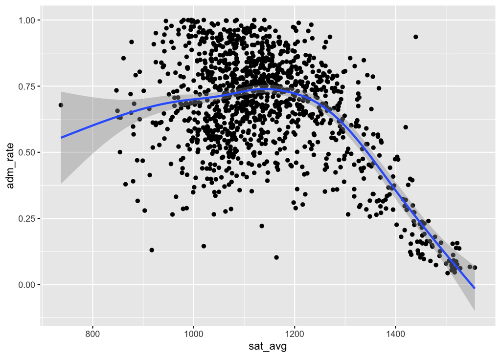

```r
## Plotting: bivariate
gg<-ggplot(data=df,aes(x=sat_avg,y=adm_rate))
gg<-gg+geom_point()
gg<-gg+geom_smooth()
gg
```

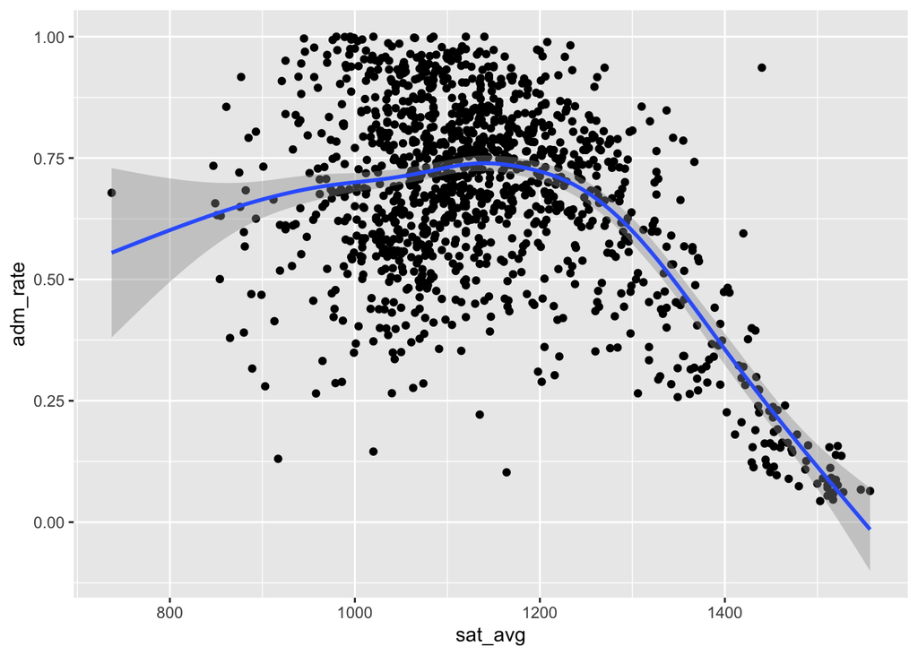

```r
df%>%
  ggplot(aes(x=sat_avg,y=adm_rate))+
  geom_point()+
  geom_smooth()
```

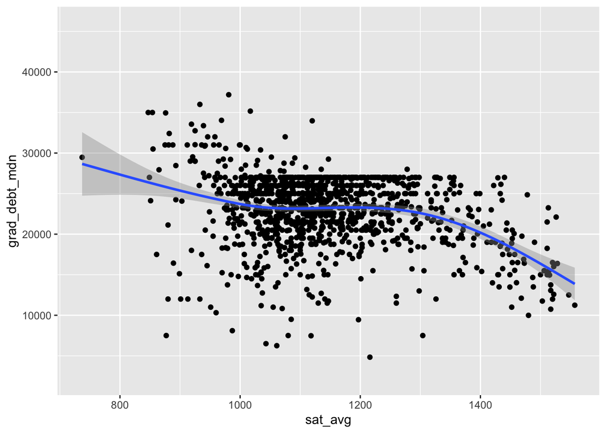

```r
gg<-ggplot(data=df,aes(x=sat_avg,y=grad_debt_mdn))
gg<-gg+geom_point()
gg<-gg+geom_smooth()
gg
```

*Quick exercise* Replicate the above plots, but put debt level on the y axis.

*How would we calculate expected debt in the middle range of SAT?*

```r
df%>%
  filter(sat_avg>1000&sat_avg<1200)%>%
  summarize(median_debt=median(grad_debt_mdn,na.rm=TRUE))
```

```
## # A tibble: 1 x 1
##   median_debt
##         <dbl>
## 1      24046.
```

## Your first commit: Hello, World!

For today, I want you to create a file called `02-assignment_<lastname>.Rmd` in your class directory. It should contain the following elements:

1. A sentence that says “Hello, World”
2. R output that summarizes one of the variables in the `sc_debt.Rds` dataset
3. R output that shows a scatterplot for two of the variables in the `sc_debt.Rds` dataset.

Lucky for you this is is also your assignment! Submit it under assignments, using the format `02-assignment_<lastname>.Rmd`. All assignments should be turned in using this format. Since my last name is Doyle, I would use `02-assignment_doyle.Rmd` as my file name. Unless your name is also Doyle, you should use a different name.

*Stretch Items*

If you have extra time, you can do the following:

1. Calculate the average earnings for individuals at the most selective colleges, then compare that with individuals at the least selective colleges in the dataset.
2. Find a way to determine whether colleges with very high SAT scores tend to have higher or lower debt than colleges with low SAT scores.
3. Plot the relationship between SAT and debt. What do you see? Does this surprise you?
4. Now, provide separate plots for SAT and debt by control of the institution.